# Die IRBA-Formel gem. Art. 153 CRR

Kapitalanforderungen für Risikopositionen

Lara Daub

2026-11-16

## 1. Intro und Überblick

Der **Internal Ratings-Based Approach (IRBA)** erlaubt es Banken, eigene Schätzungen für Risikoparameter zu nutzen, um die Eigenmittelanforderungen zu berechnen.

Für Risikopositionen an Unternehmen (Corporate Exposures) liefert **Art. 153 CRR** die exakte Berechnungsgrundlage.

**Agenda dieser Kurz-Präsentation:**

- **Die Formel:** Wie setzt sich das Risikogewicht (RW) zusammen?
- **Hintergrund:** Welche Rolle spielen die Parameter PD, LGD und M?
- **Visuelle Analyse:** Ein 3D-Plot zur Wirkung von PD und LGD auf das Risikogewicht.
- **Simuliertes Portfolio**
- **Auswertung des Beispielportfolios**
- **Relative Sensitivität PD/ LGD**
- **Vorteilhaftigkeit des IRBA** Erste Überlegungen
- **Ausblick**

## 2. Die IRBA-Formel (Art. 153 CRR)

Das Risikogewicht ($RW$) für Corporates berechnet sich nach einer fest definierten aufsichtlichen Funktion:

$$\begin{align*}
RW = &\left( LGD \cdot N \left( \frac{G(PD) + \sqrt{R} \cdot G(0.999)}{\sqrt{1-R}} \right) - LGD \cdot PD \right) \\ \\
&\cdot \frac{1 + (M - 2.5) \cdot b}{1 - 1.5 \cdot b} \cdot 12.5 \cdot 1.06
\end{align*}$$

**Die mathematischen Operatoren:**

- $N(x)$: Verteilungsfunktion der Standardnormalverteilung
- $G(z)$: Inverse der Standardnormalverteilung (Quantilsfunktion)
- $R$: Korrelation (ein von der PD abhängiger Wert)
- $b$: Laufzeitanpassungsfaktor (abhängig von der PD)

## 3. Die granularen Risikoparameter

Um das Risikogewicht exakt berechnen und überwachen zu können, sind nicht nur die finalen Ratings entscheidend, sondern die genauen Inputfaktoren. Die drei Kernparameter sind:

- **PD (Probability of Default):** Die Ausfallwahrscheinlichkeit. Gibt an, wie wahrscheinlich es ist, dass der Schuldner innerhalb des nächsten Jahres ausfällt.
- **LGD (Loss Given Default):** Die Verlustquote bei Ausfall. Welcher prozentuale Anteil des ausstehenden Betrags geht im Ausfall tatsächlich verloren? (Maßgeblich durch Sicherheiten beeinflusst).
- **M (Maturity):** Die effektive Restlaufzeit in Jahren. Spiegelt das Risiko wider, dass sich die Bonität über die Zeit verschlechtert.

**Note**

**Unerwarteter Verlust (Unexpected Loss):** Der Term $G(0.999)$ stellt sicher, dass das Eigenkapital für extreme Verluste (99,9%-Konfidenz) in Krisenzeiten ausreicht. Der reine Standardrisikokosten-Anteil (Erwarteter Verlust: $PD \cdot LGD$) wird in der Klammer der Formel wieder abgezogen.

## 4. Visuelle Analyse: RW-Sensitivität

```r
# #| output-location: column
#| message: false
#| warning: false

# Grid für PD (0.1% bis 20%) und LGD (10% bis 100%) definieren
pd_seq <- seq(0.001, 0.20, length.out = 50)
lgd_seq <- seq(0.10, 1.00, length.out = 50)

# Funktion zur RW-Berechnung gem. Art 153 CRR (vereinfacht für M=2.5)
calc_rw <- function(pd, lgd) {
  # Korrelation R
  r <- 0.12 * (1 - exp(-50 * pd)) / (1 - exp(-50)) +
       0.24 * (1 - (1 - exp(-50 * pd)) / (1 - exp(-50)))

  # Inverse und Verteilungsfunktion der Standardnormalverteilung via stats::
  term1 <- stats::qnorm(pd) + sqrt(r) * stats::qnorm(0.999)
  term2 <- term1 / sqrt(1 - r)

  # RW-Berechnung
  rw <- (lgd * stats::pnorm(term2) - lgd * pd) * 12.5 * 1.06

  return(rw * 100) # als Prozentwert
}

# Matrix für den Plot berechnen
rw_matrix <- outer(pd_seq, lgd_seq, Vectorize(calc_rw))

# Interaktiven 3D Surface Plot mit expliziten Namespaces und nativer Pipe
plotly::plot_ly(x = ~lgd_seq, y = ~pd_seq, z = ~rw_matrix,
                width = 800, height = 450) |>
  plotly::add_surface(colorscale = "Viridis") |>
  plotly::layout(
    autosize = FALSE,
    scene = list(
      xaxis = list(title = 'LGD', tickformat = ".0%"),
      yaxis = list(title = 'PD', tickformat = ".1%"),
      zaxis = list(title = 'RW in %')
    )
  )
```

[interactive chart not shown]

## 5. Portfolio-Übersicht (Simulierte Daten)

Eine interaktive Übersicht der Corporate-Positionen inklusive der zugehörigen Risikoparameter. Über die Spaltenköpfe kann gezielt gefiltert werden.

| Kunde | Rating | EAD | PD | LGD |
| --- | --- | --- | --- | --- |
| Corp_1 | AA | 4256636.79 | 0.0006 | 0.17 |
| Corp_2 | AA | 407457.03 | 0.0007 | 0.44 |
| Corp_3 | Unrated | 4117240.93 | 0.0118 | 0.16 |
| Corp_4 | B | 2742865.44 | 0.0624 | 0.43 |
| Corp_5 | BB | 2545198.48 | 0.0141 | 0.26 |
| Corp_6 | BB | 208913.87 | 0.0281 | 0.36 |
| Corp_7 | A | 2815056.36 | 0.0029 | 0.32 |
| Corp_8 | BBB | 3627498.25 | 0.0052 | 0.24 |
| Corp_9 | BB | 1255004.62 | 0.0283 | 0.15 |
| Corp_10 | A | 4078210.44 | 0.0021 | 0.28 |

[output cut: 490 more lines]

## 6. Auswertung Portfolio-Daten

Aus diesen Corporate-Positionen ergeben sich nun mittels IRBA und KSA folgende Werte für RWA und Eigenmittelunterlegung:

Vergleich KSA und IRBA

| Verfahren | RWA (in €) | Eigenmittelunterlegung (in €) |
| --- | --- | --- |
| KSA | 1.060.443.489,00 | 84.835.479,12 |
| IRBA | 644.223.474,44 | 51.537.877,96 |

## 7. relative Sensitivität von PD und LGD

LGD: als einfacher Faktor der RW-Funktion ist die relative Sensitivität gegenüber der LGD konstant 1

$$S_{LGD}
=
\frac{\partial RW}{\partial LGD}
\cdot
\frac{LGD}{RW}
= 1$$
PD: nicht-linearer Einfluss auf die Risikogewichte
$$S_{PD} =
\frac{\partial RW}{\partial PD}
\cdot
\frac{PD}{RW}$$

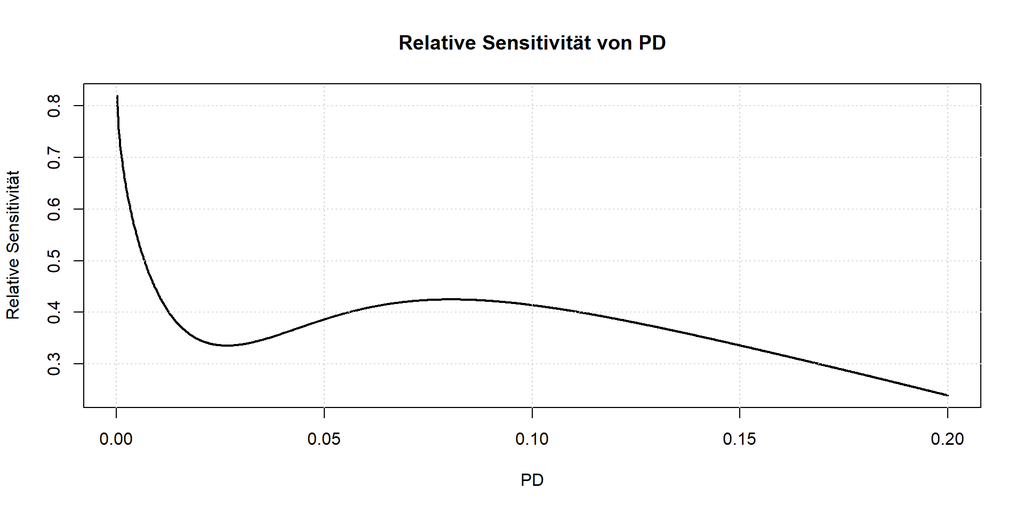

## 8. IRBA vs. KSA - Szenarien einer relativen Vorteilhaftigkeit

Erste Überlegung:

RW im KSA zwischen 20% und 150% begrenzt

Mit welchen PD und LGD liegt der IRBA darüber bzw. darunter?

[interactive chart not shown]

## 9. Ausblick und weiterführende Fragestellungen

- regulatorische Restriktionen: Einfluss von Input- und Outputfloor auf den IRBA-Vorteil
- Einfluss der Bonitätsstruktur: Auswirkung unterschiedlicher Ratingverteilungen im Unternehmensportfolio auf die RWA
- Wirtschaftlche Perspektive: Gegenüberstellung der möglichen Eigenkapitalersparnis und des zusätzlichen Aufwands für die IRBA Anwendung